# Exploring the BRFSS data

## Setup

**Load packages**

```r
library(ggplot2)
library(dplyr)
library(knitr)
```

**Load data**

Make sure your data and R Markdown files are in the same directory. When loaded your data file will be called `brfss2013`. Delete this note when before you submit your work.

```r
load("brfss2013.RData")
```

## Part 1: Data

**Overview**

The Behavioral Risk Factor Surveillance System (BRFSS) is an ongoing system designed to measure behavioral risk factors for the adult population (> 18 years old) in the US. It collects state data about U.S. residents regarding their health-related risk behaviors, chronic health conditions, and use of preventive services through telephone surveys. Initiated in 1984, BRFSS collected surveillance data on risk behaviors through monthly telephone interviews with 15 states. BRFSS now collects data in all 50 states as well as the District of Columbia and three U.S. territories. BRFSS completes more than 400,000 adult interviews each year.

**Survey Method**

The data is collected through telephone surveys. The surveys are conducted using Random Digit Dialing (RDD) techniques on both landlines and cell phones. RDD is a method for selecting people for involvement in telephone statistical surveys by generating telephone numbers at random.

**Generalizability**

Regarding the survey method, data is collected through random sampling and hence can be generalized to the entire population. However, certain issues suggested potential bias of the results.

Assuming the US has a high telephone-ownership rate, when phone numbers are generated at random, each case in the population has an equal chance of being included and there is no implied connection between the cases in the sample. Hence, the data collected is regarded as random sample and it is believed to be representative of the population. Observational results from the sample can be generalized to the population.

Nevertheless, under a few circumstance, it is unclear whether the results are representative of the entire population. First, there would be bias introduced by non-responders. Non-response bias can be a problem if responders differ from non-responders for the measured variables. For example, non-responders may not have been contacted because they work multiple minimum-wage jobs. There would also be bias of voluntary responses, as people more interested in the subject tend to pay more attention and answer the questions. Further, it may occur that participants do not honestly answer some of the most sensitive questions about their health status, which carries the risk of a response bias.

**Causality**

Inference of a causal connection can only be done through experiment with random assignment. There is no evidence that random assignment is used with reference to the survey method. Hence, the data is not applicable to causal inference.

## Part 2: Research questions

**Research Question 1**

Surveys found that women are more likely to have mental health problems than men, with young women at particularly high risk. In the society, there are often strong bias towards certain gender and age groups on mental issues. Are gender and age associated with mental health?

**Research Question 2**

Relationship is considered to be correlated with health. Great marriage can bring better psychological health. An unsatisfying marriage may raise stress and worsen our well-being. How relationship status is associated with mental health? Do men and women behave differently to relationship effects?

**Research Question 3**

Taking up exercise seems to reduce the risk of developing mental illness. It also seems to help in treating some mental health conditions. Do physical activities improve a person’s mental health? How does the quantity and type of physical activities influence the results?

## Part 3: Exploratory data analysis

### Research Question 1

*Are gender and age associated with mental health?*

#### Data Preparation

The variables we’ll use in this analysis include:

- `menthlth` — Number of days (during the past 30 days) mental health not good
- `sex` — Respondent’s sex
- `age_group` (renamed from `X_age_g`) — Imputed age in six groups

```r
data_1 <- brfss2013 %>%
  rename(age_group = X_age_g) %>%
  select(menthlth, sex, age_group)
```

First we clean our data by removing observations with missing values. For `menthlth`, since the survey question asked about the number of days of mental health not good in the past 30 days, 30 is the maximum value. Observations with unreasonable values are also removed.

```r
data_1 <- data_1 %>%
  filter(
    !is.na(menthlth), !is.na(sex), !is.na(age_group),
    menthlth <= 30
  )
```

We also create a new variable as a binary indicator of whether the respondant has at least one day of mental issue in the pass 30 days from `menthlth`:

- `mental_disorder` — More than 0 days of mental health not good

```r
data_1 <- data_1 %>%
  mutate(mental_disorder = as.numeric(menthlth > 0))
```

```r
kable(head(data_1))
```

| menthlth | sex | age_group | mental_disorder |
| --- | --- | --- | --- |
| 29 | Female | Age 55 to 64 | 1 |
| 0 | Female | Age 45 to 54 | 0 |
| 2 | Female | Age 55 to 64 | 1 |
| 0 | Female | Age 55 to 64 | 0 |
| 2 | Male | Age 65 or older | 1 |
| 0 | Female | Age 45 to 54 | 0 |

#### Data Analysis

To get started, we compute the probabiliy of having mental disorders.

```r
mean(data_1$mental_disorder)
```

```
## [1] 0.3077445
```

The probability of having mental disorders is 0.3.

If gender and age are independent of mental disorders, there should be no significant difference in the probability of mental disorder between different gender and age groups.

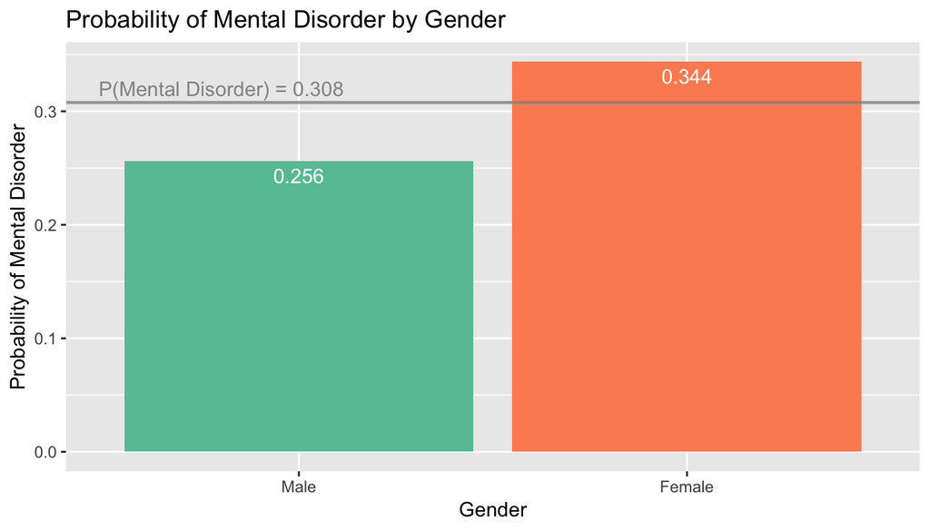

```r
data_1 %>%
  group_by(sex) %>%
  summarise(mental_disorder = mean(mental_disorder)) %>%
  ggplot(aes(x = sex, y = mental_disorder)) +
  geom_col(aes(fill = sex)) +
  geom_text(aes(label = round(mental_disorder, 3)), vjust = 1.5, color = 'white') +
  geom_hline(
    yintercept = mean(data_1$mental_disorder),
    color = 'gray58', size = .8, alpha = .8
  ) +
  annotate(
    'text', x = .8, y = .32, color = 'gray58',
    label = 'P(Mental Disorder) = 0.308'
  ) +
  labs(
    title = "Probability of Mental Disorder by Gender",
    x = "Gender", y = "Probability of Mental Disorder"
  ) +
  theme(legend.position = 'none') +
  scale_fill_brewer(palette = 'Set2')
```

It is found that the probability of having mental disorder of female (0.344) is higher than male (0.256). This result shows some evidence that gender is not independent from mental disorder, and female has a higher probability of having mental problems.

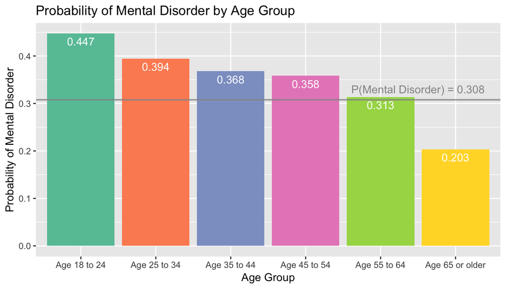

```r
data_1 %>%
  group_by(age_group) %>%
  summarise(mental_disorder = mean(mental_disorder)) %>%
  ggplot(aes(x = age_group, y = mental_disorder)) +
  geom_col(aes(fill = age_group)) +
  geom_text(aes(label = round(mental_disorder, 3)), vjust = 1.5, color = 'white') +
  geom_hline(
    yintercept = mean(data_1$mental_disorder),
    color = 'gray58', size = .7, alpha = .8
  ) +
  annotate(
    'text', x = 5.5, y = .33, color = 'gray58',
    label = 'P(Mental Disorder) = 0.308'
  ) +
  labs(
    title = "Probability of Mental Disorder by Age Group",
    x = "Age Group", y = "Probability of Mental Disorder"
  ) +
  theme(legend.position = 'none') +
  scale_fill_brewer(palette = 'Set2')
```

Evidence also shows that age might not be independent from mental problems. Younger respondants have a higher probability of having mental disorder. The observation shows that when age increases, the probability of having mental disorder decreases. Age 18 to 24 respondants have the highest probability of mental disorder (0.447). Elderly respondants with age 65 or older have the lowest probability of mental disorder (0.203).

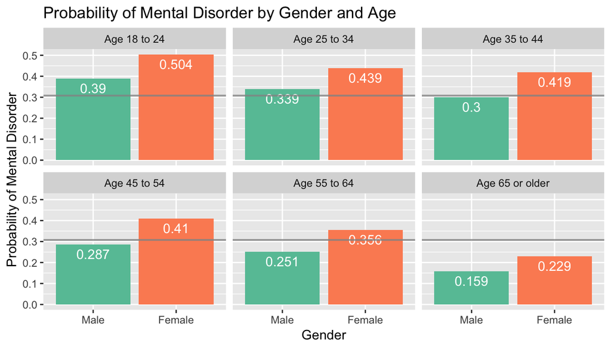

```r
data_1 %>%
  group_by(sex, age_group) %>%
  summarise(mental_disorder = mean(mental_disorder)) %>%
  ggplot(aes(x = sex, y = mental_disorder)) +
  geom_col(aes(fill = sex)) +
  facet_wrap(~age_group) +
  geom_text(aes(label = round(mental_disorder, 3)), vjust = 1.5, color = 'white') +
  geom_hline(
    yintercept = mean(data_1$mental_disorder),
    color = 'gray58', size = .7, alpha = .8
  ) +
  labs(
    title = "Probability of Mental Disorder by Gender and Age",
    x = "Gender", y = "Probability of Mental Disorder"
  ) +
  theme(legend.position = 'none') +
  scale_fill_brewer(palette = 'Set2')
```

Combining both gender and age effects, we observe that female at all ages has a higher probability of having mental disorder. Young female has the highest probability of mental disorder (0.504).

#### Conclusion

It is observed that both gender and age are not independent from mental health. Female has a higher probability to have mental disorder than male, and age is negatively related to the probability of having mental disorder. Among all, young female has the highest probability of having mental disorder.

### Research Question 2

*How relationship status is associated with mental health? Do men and women behave differently to relationship effects?*

#### Data Preparation

The variables we’ll use in this analysis include:

- `menthlth` — Number of days (during the past 30 days) mental health not good
- `sex` — Respondent’s sex
- `marital` — Marital Status

```r
data_2 <- brfss2013 %>%
  rename(age_group = X_age_g) %>%
  select(menthlth, sex, marital, age_group)
```

We clean the data in the same way as in research question 1, and we create the same binary response variable from `menthlth` as in the previous analysis:

- `mental_disorder` — More than 0 days of mental health not good

```r
data_2 <- data_2 %>%
  filter(
    !is.na(menthlth), !is.na(sex), !is.na(marital), !is.na(age_group),
    menthlth <= 30
  ) %>%
  mutate(
    mental_disorder = as.numeric(menthlth > 0),
    marital = stringr::str_replace(marital, "A member of an unmarried couple", "Unmarried couple")
  )
```

```r
kable(head(data_2))
```

| menthlth | sex | marital | age_group | mental_disorder |
| --- | --- | --- | --- | --- |
| 29 | Female | Divorced | Age 55 to 64 | 1 |
| 0 | Female | Married | Age 45 to 54 | 0 |
| 2 | Female | Married | Age 55 to 64 | 1 |
| 0 | Female | Married | Age 55 to 64 | 0 |
| 2 | Male | Married | Age 65 or older | 1 |
| 0 | Female | Divorced | Age 45 to 54 | 0 |

#### Data Analysis

```r
mean(data_2$mental_disorder)
```

```
## [1] 0.307917
```

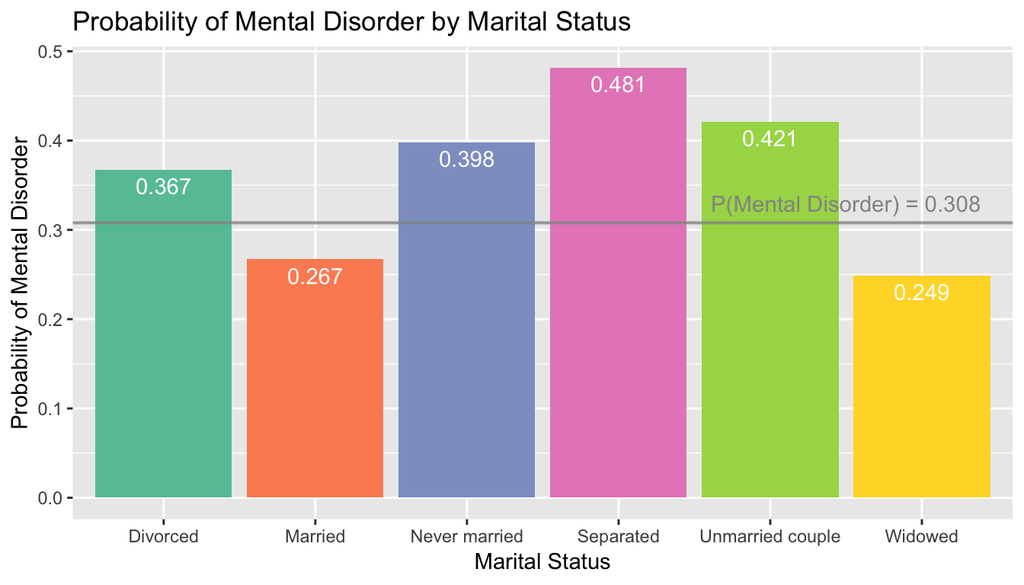

```r
data_2 %>%
  group_by(marital) %>%
  summarise(mental_disorder = mean(mental_disorder)) %>%
  ggplot(aes(x = marital, y = mental_disorder)) +
  geom_col(aes(fill = marital)) +
  geom_text(aes(label = round(mental_disorder, 3)), vjust = 1.5, color = 'white') +
  geom_hline(
    yintercept = mean(data_2$mental_disorder),
    color = 'gray58', size = .7, alpha = .8
  ) +
  annotate(
    'text', x = 5.5, y = .33, color = 'gray58',
    label = 'P(Mental Disorder) = 0.308'
  ) +
  labs(
    title = "Probability of Mental Disorder by Marital Status",
    x = "Marital Status", y = "Probability of Mental Disorder"
  ) +
  theme(legend.position = 'none') +
  scale_fill_brewer(palette = 'Set2')
```

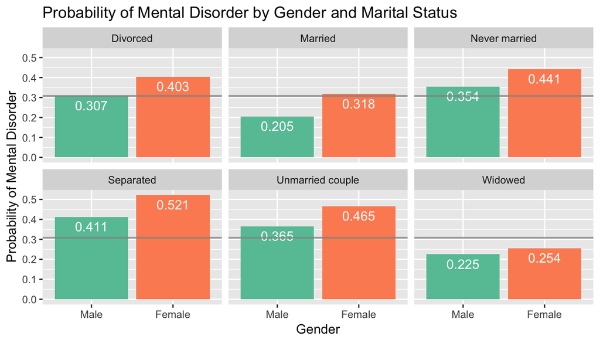

```r
data_2 %>%
  group_by(sex, marital) %>%
  summarise(mental_disorder = mean(mental_disorder)) %>%
  ggplot(aes(x = sex, y = mental_disorder)) +
  geom_col(aes(fill = sex)) +
  facet_wrap(~marital) +
  geom_text(aes(label = round(mental_disorder, 3)), vjust = 1.5, color = 'white') +
  geom_hline(
    yintercept = mean(data_2$mental_disorder),
    color = 'gray58', size = .7, alpha = .8
  ) +
  labs(
    title = "Probability of Mental Disorder by Gender and Marital Status",
    x = "Gender", y = "Probability of Mental Disorder"
  ) +
  theme(legend.position = 'none') +
  scale_fill_brewer(palette = 'Set2')
```

```r
mean(data_2$menthlth)
```

```
## [1] 3.372837
```

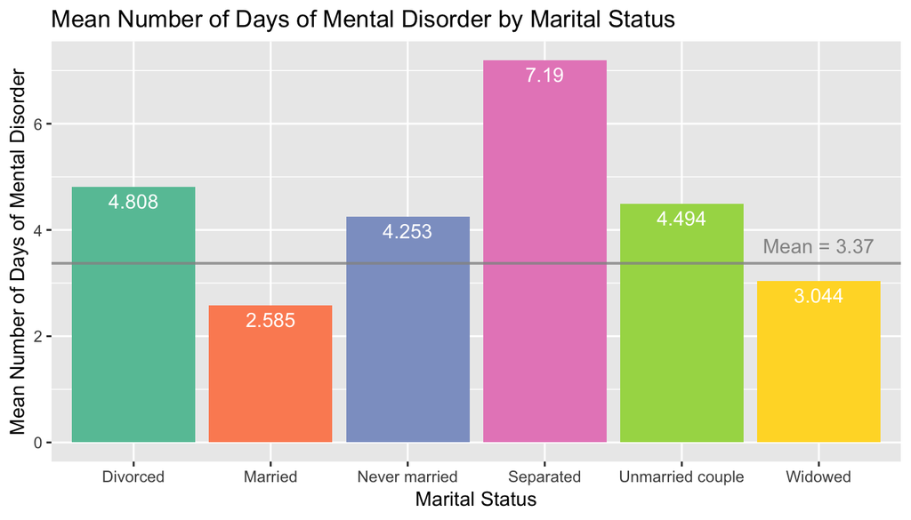

```r
data_2 %>%
  group_by(marital) %>%
  summarise(menthlth = mean(menthlth)) %>%
  ggplot(aes(x = marital, y = menthlth)) +
  geom_col(aes(fill = marital)) +
  geom_text(aes(label = round(menthlth, 3)), vjust = 1.5, color = 'white') +
  geom_hline(
    yintercept = mean(data_2$menthlth),
    color = 'gray58', size = .7, alpha = .8
  ) +
  annotate(
    'text', x = 6, y = 3.7, color = 'gray58',
    label = 'Mean = 3.37'
  ) +
  labs(
    title = "Mean Number of Days of Mental Disorder by Marital Status",
    x = "Marital Status", y = "Mean Number of Days of Mental Disorder"
  ) +
  theme(legend.position = 'none') +
  scale_fill_brewer(palette = 'Set2')
```

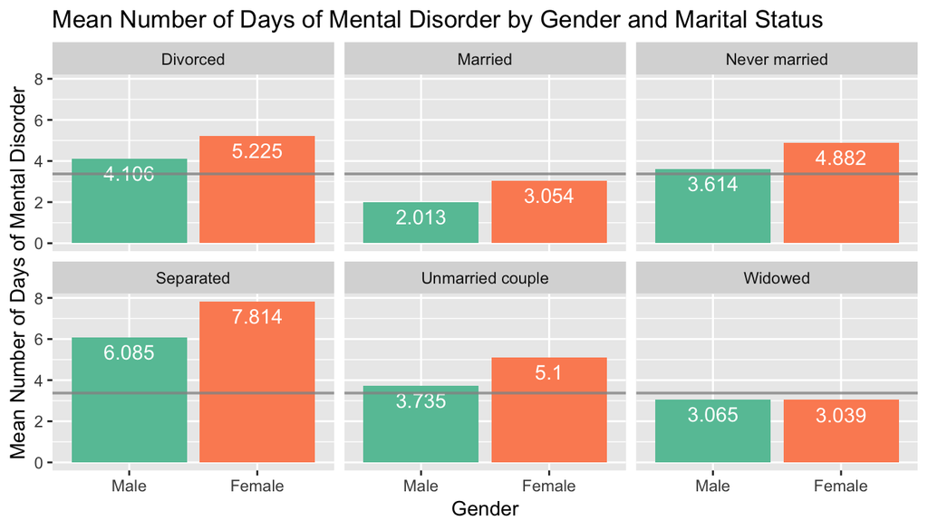

```r
data_2 %>%
  group_by(sex, marital) %>%
  summarise(menthlth = mean(menthlth)) %>%
  ggplot(aes(x = sex, y = menthlth)) +
  geom_col(aes(fill = sex)) +
  facet_wrap(~marital) +
  geom_text(aes(label = round(menthlth, 3)), vjust = 1.5, color = 'white') +
  geom_hline(
    yintercept = mean(data_2$menthlth),
    color = 'gray58', size = .7, alpha = .8
  ) +
  labs(
    title = "Mean Number of Days of Mental Disorder by Gender and Marital Status",
    x = "Gender", y = "Mean Number of Days of Mental Disorder"
  ) +
  theme(legend.position = 'none') +
  scale_fill_brewer(palette = 'Set2')
```

### Research Question 3

*Do physical activities improve a person’s mental health? How does the quantity and type of physical activities influence the results?*

#### Data Preparation

The variables we’ll use in this analysis include:

- `menthlth` — Number of days (during the past 30 days) mental health not good
- `exercise` (renamed from `exerany2`) — Exercise In Past 30 Days
- `exercise_type` (renamed from `X_parec1`) — Whether the aerobic and strengthening guideline is met
- `exercise_150` (renames from `X_pa150r2`) — 150 minute physical activity calculated variable
- `exercise_300` (renames from `X_pa300r2`) — 300 minute physical activity calculated variable

```r
data_3 <- brfss2013 %>%
  rename(
    exercise = exerany2,
    exercise_type = X_parec1,
    exercise_150 = X_pa150r2,
    exercise_300 = X_pa300r2
  ) %>%
  select(menthlth, exercise, exercise_type, exercise_150, exercise_300)
```

We clean the data in the same way as in research question 1 and 2. We create the same binary response variable from `menthlth` as in the previous analysis, and also merge `exercise_150` and `exercise_300` into one variable:

- `mental_disorder` — More than 0 days of mental health not good
- `exercise_time` — Minutes of physical activities

```r
data_3 <- data_3 %>%
  filter(
    !is.na(menthlth), !is.na(exercise), !is.na(exercise_type), !is.na(exercise_150), !is.na(exercise_300),
    menthlth <= 30
  ) %>%
  mutate(
    mental_disorder = as.numeric(menthlth > 0),
    exercise_time = case_when(
      exercise_300 == "301+ minutes" ~ "301+ minutes",
      exercise_150 == "150+ minutes" & exercise_300 == "1-300 minutes" ~ "150-300 minutes",
      exercise_150 == "1-149 minutes" ~ "1-149 minutes",
      exercise_150 == "0 minutes" ~ "0 minutes"
    )
  ) %>%
  select(-exercise_150, -exercise_300)
```

```r
kable(head(data_3))
```

| menthlth | exercise | exercise_type | mental_disorder | exercise_time |
| --- | --- | --- | --- | --- |
| 29 | No | Did not meet either guideline | 1 | 0 minutes |
| 0 | Yes | Did not meet either guideline | 0 | 1-149 minutes |
| 2 | No | Did not meet either guideline | 1 | 0 minutes |
| 0 | Yes | Did not meet either guideline | 0 | 1-149 minutes |
| 2 | No | Did not meet either guideline | 1 | 0 minutes |
| 0 | Yes | Did not meet either guideline | 0 | 1-149 minutes |